# Analisis de resultados Rubus glaucus

# Analisis de varianza para % de Severidad de Oidium

|  | Df | Sum Sq | Mean Sq | F value | Pr(>F) |
| --- | --- | --- | --- | --- | --- |
| Cultivo | 2 | 617.9874 | 308.99368 | 37.95781 | 7.052898e-10 |
| Residuals | 39 | 317.4775 | 8.14045 | NA | NA |

|  | Cultivo | emmean | SE | df | lower.CL | upper.CL | .group |
| --- | --- | --- | --- | --- | --- | --- | --- |
| 1 | Brazos | 1.035714 | 0.7625357 | 39 | -0.5066598 | 2.578088 | a |
| 3 | San Antonio | 6.660714 | 0.7625357 | 39 | 5.1183402 | 8.203088 | b |
| 2 | Castilla | 10.366071 | 0.7625357 | 39 | 8.8236974 | 11.908445 | c |

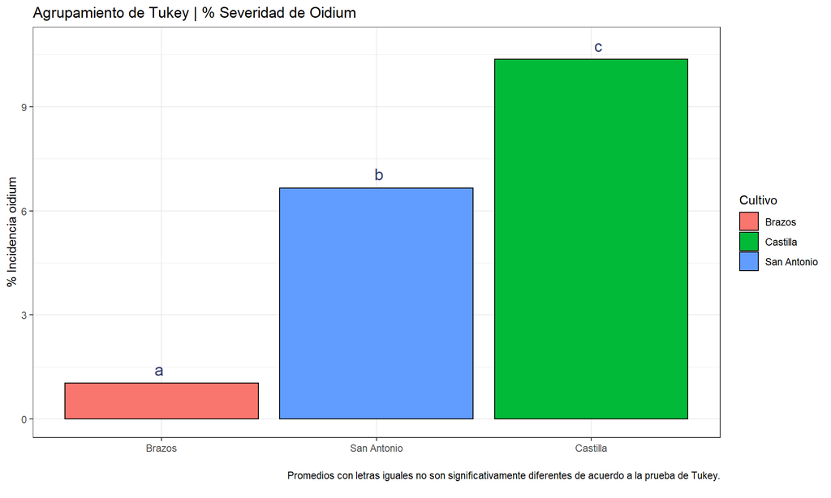

# Antracnosis Botritis y Mildeo Velloso

En la siguiente grafica se puede notar las evaluaciones de *Antracnosis, Botritis y Mildeo Velloso* para el periodo 2021 del porcentaje de incidencia y severidad. El material Brazos resultó ser bastante suceptible a Antracnosis y muy tolerante a Botritis y a Mildeo Velloso. Castilla sin espinas y San Antonio fueron medianamente tolerantes a todas las enfermedades.

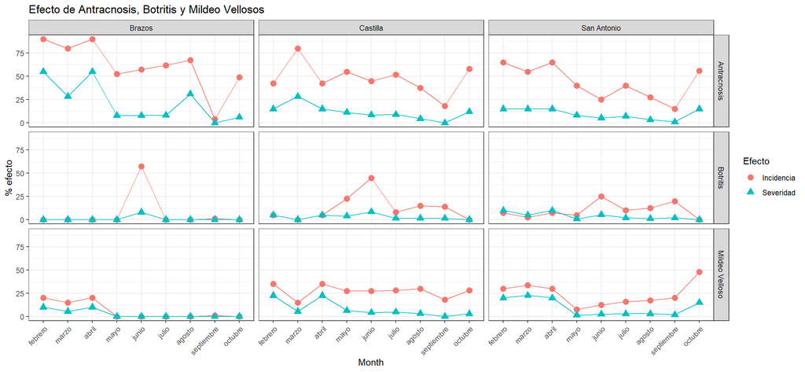

A continuación se muestra la grafica correspondiente al promedio de todo el periodo de evaluación; en donde se puede concluir que la enfermedad mas agresiva fue Antracnosis, seguida de Mildeo Vellosos y finalmente Botritis. Adicionalmente el material Brazos fue el que mas mostró suceptibilidad a Antracnosis pero simultaneamente fue el mas resistencia tuvo con Botritis y Mildeo Velloso. Los materiales Castilla y San antonio mostrarón mediana suceptibilidad a Botritis y Mildeo Velloso.

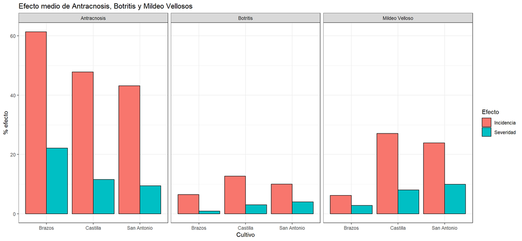

# Analisis de varianza para Incidencia y severidad de Antracnosis

## Severidad de Antracnosis

|  | Df | Sum Sq | Mean Sq | F value | Pr(>F) |
| --- | --- | --- | --- | --- | --- |
| Cultivo | 2 | 835.3946 | 417.6973 | 2.280952 | 0.1239051 |
| Residuals | 24 | 4394.9794 | 183.1241 | NA | NA |

|  | Cultivo | emmean | SE | df | lower.CL | upper.CL | .group |
| --- | --- | --- | --- | --- | --- | --- | --- |
| 3 | San Antonio | 9.466667 | 4.510779 | 24 | 0.1568764 | 18.77646 | a |
| 2 | Castilla | 11.527778 | 4.510779 | 24 | 2.2179875 | 20.83757 | a |
| 1 | Brazos | 22.161111 | 4.510779 | 24 | 12.8513209 | 31.47090 | a |

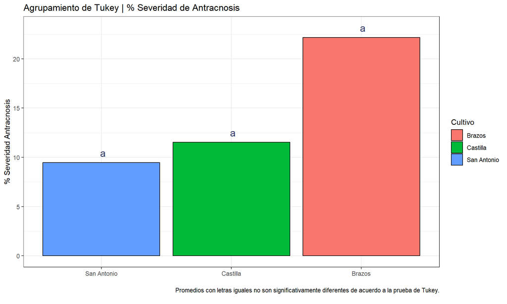

## Icidencia de Antracnosis

|  | Df | Sum Sq | Mean Sq | F value | Pr(>F) |
| --- | --- | --- | --- | --- | --- |
| Cultivo | 2 | 1612.741 | 806.3704 | 1.847022 | 0.1794314 |
| Residuals | 24 | 10477.889 | 436.5787 | NA | NA |

|  | Cultivo | emmean | SE | df | lower.CL | upper.CL | .group |
| --- | --- | --- | --- | --- | --- | --- | --- |
| 3 | San Antonio | 43.16667 | 6.964822 | 24 | 28.79198 | 57.54135 | a |
| 2 | Castilla | 47.83333 | 6.964822 | 24 | 33.45865 | 62.20802 | a |
| 1 | Brazos | 61.38889 | 6.964822 | 24 | 47.01420 | 75.76357 | a |

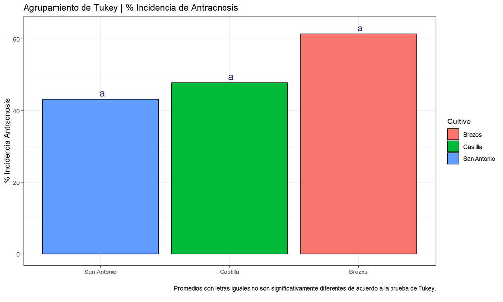

# Analisis de varianza para Incidencia y severidad de Botritis

## Severidad de Botritis

|  | Df | Sum Sq | Mean Sq | F value | Pr(>F) |
| --- | --- | --- | --- | --- | --- |
| Cultivo | 2 | 46.17019 | 23.085093 | 2.334989 | 0.118415 |
| Residuals | 24 | 237.27833 | 9.886597 | NA | NA |

|  | Cultivo | emmean | SE | df | lower.CL | upper.CL | .group |
| --- | --- | --- | --- | --- | --- | --- | --- |
| 1 | Brazos | 0.8888889 | 1.048099 | 24 | -1.2742804 | 3.052058 | a |
| 2 | Castilla | 3.0111111 | 1.048099 | 24 | 0.8479418 | 5.174280 | a |
| 3 | San Antonio | 4.0277778 | 1.048099 | 24 | 1.8646085 | 6.190947 | a |

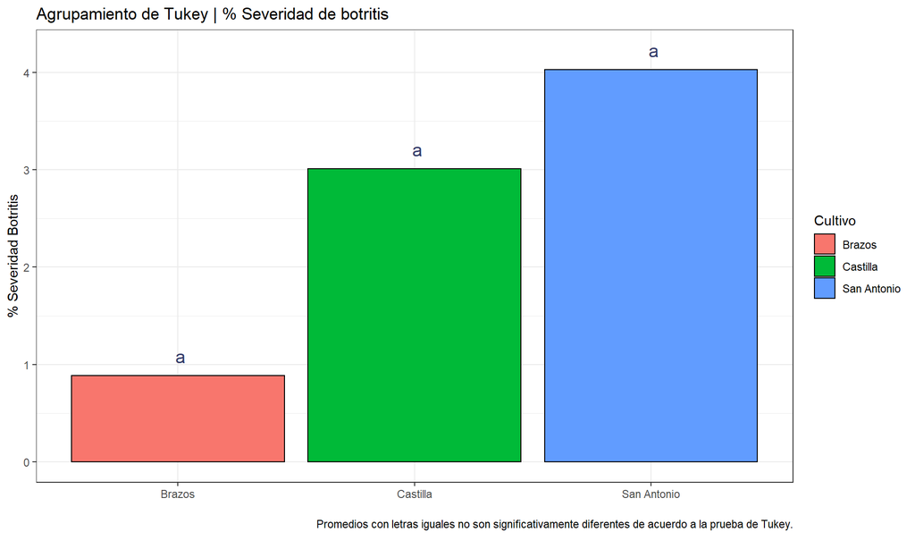

## Icidencia de botritis

|  | Df | Sum Sq | Mean Sq | F value | Pr(>F) |
| --- | --- | --- | --- | --- | --- |
| Cultivo | 2 | 175.1296 | 87.56481 | 0.4151995 | 0.6648605 |
| Residuals | 24 | 5061.5556 | 210.89815 | NA | NA |

|  | Cultivo | emmean | SE | df | lower.CL | upper.CL | .group |
| --- | --- | --- | --- | --- | --- | --- | --- |
| 1 | Brazos | 6.50000 | 4.840778 | 24 | -3.490873883 | 16.49087 | a |
| 3 | San Antonio | 10.00000 | 4.840778 | 24 | 0.009126117 | 19.99087 | a |
| 2 | Castilla | 12.72222 | 4.840778 | 24 | 2.731348339 | 22.71310 | a |

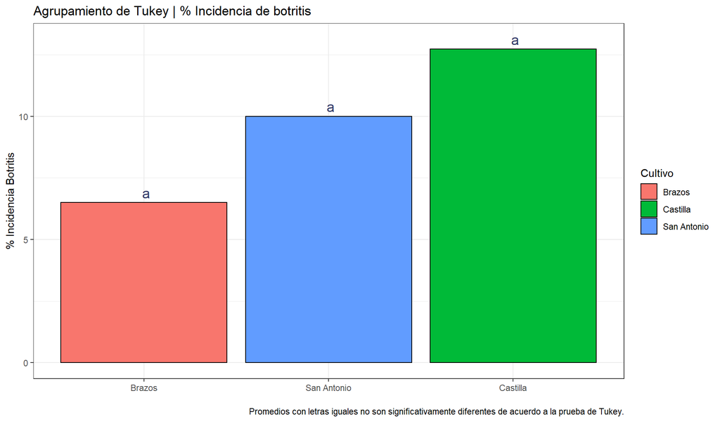

# Analisis de varianza para Incidencia y severidad de Mildeo Velloso

## Severidad de Mildeo Velloso

|  | Df | Sum Sq | Mean Sq | F value | Pr(>F) |
| --- | --- | --- | --- | --- | --- |
| Cultivo | 2 | 245.7269 | 122.86343 | 2.106753 | 0.1435656 |
| Residuals | 24 | 1399.6528 | 58.31887 | NA | NA |

|  | Cultivo | emmean | SE | df | lower.CL | upper.CL | .group |
| --- | --- | --- | --- | --- | --- | --- | --- |
| 1 | Brazos | 2.833333 | 2.54556 | 24 | -2.420444 | 8.08711 | a |
| 2 | Castilla | 8.055556 | 2.54556 | 24 | 2.801779 | 13.30933 | a |
| 3 | San Antonio | 9.972222 | 2.54556 | 24 | 4.718445 | 15.22600 | a |

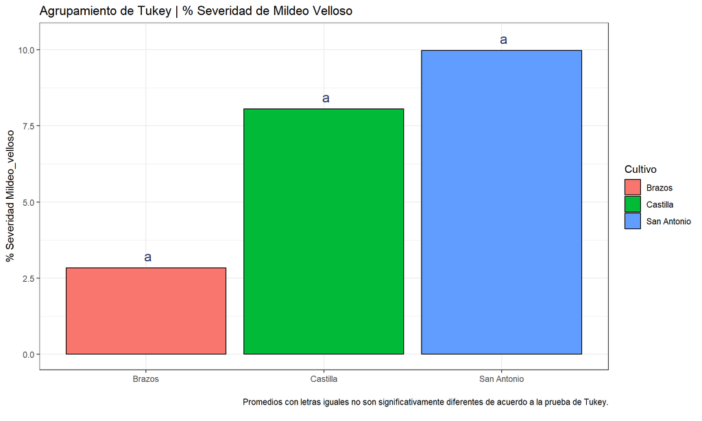

## Icidencia de Mildeo Velloso

|  | Df | Sum Sq | Mean Sq | F value | Pr(>F) |
| --- | --- | --- | --- | --- | --- |
| Cultivo | 2 | 2278.931 | 1139.4653 | 11.82992 | 0.0002658908 |
| Residuals | 24 | 2311.694 | 96.3206 | NA | NA |

|  | Cultivo | emmean | SE | df | lower.CL | upper.CL | .group |
| --- | --- | --- | --- | --- | --- | --- | --- |
| 1 | Brazos | 6.222222 | 3.271435 | 24 | -0.5296884 | 12.97413 | a |
| 3 | San Antonio | 23.916667 | 3.271435 | 24 | 17.1647560 | 30.66858 | b |
| 2 | Castilla | 27.111111 | 3.271435 | 24 | 20.3592004 | 33.86302 | b |

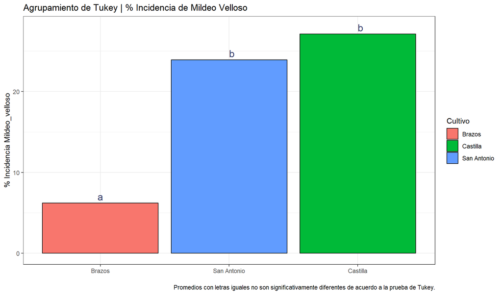